# Stout Case Study 1: Decision Tree Regression

Theresa Pham

12/22/2022

```r
loans<-read.csv("loans_full_schema.csv")
glimpse(loans)
```

```
## Rows: 10,000
## Columns: 55
## $ emp_title                        <chr> "global config engineer ", "warehouse~
## $ emp_length                       <int> 3, 10, 3, 1, 10, NA, 10, 10, 10, 3, 1~
## $ state                            <chr> "NJ", "HI", "WI", "PA", "CA", "KY", "~
## $ homeownership                    <chr> "MORTGAGE", "RENT", "RENT", "RENT", "~
## $ annual_income                    <dbl> 90000, 40000, 40000, 30000, 35000, 34~
## $ verified_income                  <chr> "Verified", "Not Verified", "Source V~
## $ debt_to_income                   <dbl> 18.01, 5.04, 21.15, 10.16, 57.96, 6.4~
## $ annual_income_joint              <dbl> NA, NA, NA, NA, 57000, NA, 155000, NA~
## $ verification_income_joint        <chr> "", "", "", "", "Verified", "", "Not ~
## $ debt_to_income_joint             <dbl> NA, NA, NA, NA, 37.66, NA, 13.12, NA,~
## $ delinq_2y                        <int> 0, 0, 0, 0, 0, 1, 0, 1, 1, 0, 0, 0, 0~
## $ months_since_last_delinq         <int> 38, NA, 28, NA, NA, 3, NA, 19, 18, NA~
## $ earliest_credit_line             <int> 2001, 1996, 2006, 2007, 2008, 1990, 2~
```

[output cut: 42 more lines]

**The purpose of this decision tree regression is to predict interest rates from a feature set of predictors**

## Cleaning

For cleaning purposes, we will omit NAs and consider only columns with 2 or more unique inputs.

```r
clean_loans <- na.omit(loans)

# number of unique observations for each variable
n_unique <- sapply(lapply(clean_loans, unique), length)

clean_loans <- clean_loans %>%
  select(-which(n_unique==1))

sapply(lapply(clean_loans, unique), length) # no more 1s
```

```
##                        emp_title                       emp_length
##                              166                               11
##                            state                    homeownership
##                               44                                3
##                    annual_income                  verified_income
##                              108                                3
##                   debt_to_income              annual_income_joint
##                              195                              148
##        verification_income_joint             debt_to_income_joint
##                                4                              198
##                        delinq_2y         months_since_last_delinq
##                                7                               71
##             earliest_credit_line               inquiries_last_12m
##                               35                               12
##               total_credit_lines                open_credit_lines
##                               46                               26
##               total_credit_limit            total_credit_utilized
##                              203                              203
##         num_collections_last_12m     num_historical_failed_to_pay
##                                2                                3
##            months_since_90d_late     total_collection_amount_ever
##                               76                               43
##     current_installment_accounts              accounts_opened_24m
##                               15                               18
## months_since_last_credit_inquiry        num_satisfactory_accounts
##                               24                               26
##        num_active_debit_accounts                total_debit_limit
##                               14                              153
##            num_total_cc_accounts             num_open_cc_accounts
##                               35                               23
##          num_cc_carrying_balance                num_mort_accounts
##                               18                                9
##     account_never_delinq_percent                        tax_liens
##                              109                                3
##           public_record_bankrupt                     loan_purpose
##                                3                                9
##                      loan_amount                             term
##                               76                                2
##                    interest_rate                      installment
##                               48                              197
##                            grade                        sub_grade
##                                6                               28
##                      issue_month                      loan_status
##                                3                                5
##           initial_listing_status              disbursement_method
##                                2                                2
##                          balance                       paid_total
##                              198                              202
##                   paid_principal                    paid_interest
##                              200                              202
##                   paid_late_fees
##                                2
```

# Building the model

We will rank the variables by importance in predicting interest rate to define the feature set.

```r
set.seed(3)

loans_ctrl <- trainControl(method="repeatedcv", number=10, repeats=3)

loans_mod <- train(interest_rate ~ ., data=clean_loans, preProcess="scale", trControl=loans_ctrl)

loans_importance <- varImp(loans_mod, scale=FALSE)

print(loans_importance)
```

```
## rf variable importance
##
##   only 20 most important variables shown (out of 301)
##
##                      Overall
## gradeE              2070.485
## gradeD              1501.104
## gradeF               922.640
## gradeC               712.833
## gradeB               311.578
## paid_interest        213.068
## sub_gradeB5           41.819
## sub_gradeC5           40.988
## sub_gradeD5           40.570
## paid_principal        39.089
## sub_gradeC4           20.312
## accounts_opened_24m   18.755
## sub_gradeC1           15.099
## sub_gradeF5           13.984
## sub_gradeE5           12.523
## sub_gradeD1           11.869
## stateHI               10.795
## sub_gradeF1           10.287
## sub_gradeA3           10.070
## sub_gradeB1            8.655
```

From the importance data frame, we will use grade and subgrade as the feature set and fit a decision tree regression model using these features. Note that decision trees make the assumption that predictors are discrete, so we excluded the continuous variables that we printed as important above.

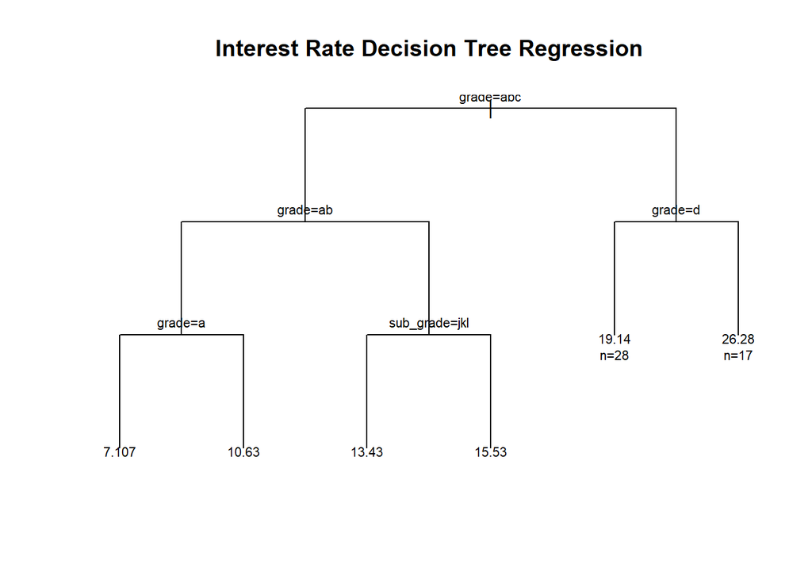

```r
# Split data into train and test sets
set.seed(9)
sort_loans  <- sort(sample(nrow(clean_loans), nrow(clean_loans)*.7))
tree_train <- clean_loans[sort_loans,]
tree_test <- clean_loans[-sort_loans,]

# Decision tree regression with feature training set
loans_treefit <- rpart(interest_rate ~ grade + sub_grade, method = "anova", data = tree_train)

plot(loans_treefit, uniform = TRUE,
          main = "Interest Rate Decision Tree Regression")
text(loans_treefit, use.n = TRUE, cex = .7)
```

```r
print(loans_treefit)
```

```
## n= 142
##
## node), split, n, deviance, yval
##       * denotes terminal node
##
##  1) root 142 4232.780000 15.22563
##    2) grade=A,B,C 97  669.888900 12.15897
##      4) grade=A,B 52  127.413300 10.09058
##        8) grade=A 8    3.077350  7.10750 *
##        9) grade=B 44   40.202320 10.63295 *
##      5) grade=C 45   62.931760 14.54911
##       10) sub_grade=C1,C2,C3 21    7.700629 13.42714 *
##       11) sub_grade=C4,C5 24    5.665383 15.53083 *
##    3) grade=D,E,F 45  684.298900 21.83600
##      6) grade=D 28   44.371870 19.13786 *
##      7) grade=E,F 17  100.352400 26.28000 *
```

## Evaluate Model

```r
# Remove additional levels from test set
tree_test <- tree_test %>%
  filter(sub_grade != "A1")

# Data frame of actual and predicted interest rates on test set
tree_pred <- as.data.frame(predict(loans_treefit, newdata=tree_test, method="anova"))

tree_test_df <- data.frame(tree_test$interest_rate, tree_pred)
colnames(tree_test_df)[1] <- "Actual"
colnames(tree_test_df)[2] <- "Predicted"
head(tree_test_df)
```

```
##   Actual Predicted
## 1   7.35   7.10750
## 2  19.03  19.13786
## 3  11.99  10.63295
## 4   9.44  10.63295
## 5   6.71   7.10750
## 6  10.90  10.63295
```

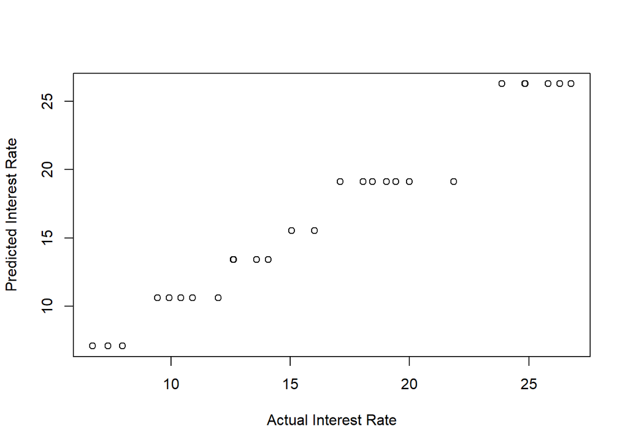

```r
# Actual vs Predicted
plot(tree_test_df$Actual, tree_test_df$Predicted,
     xlab = "Actual Interest Rate",
     ylab = "Predicted Interest Rate")
```

```r
# RMSE
tree_rmse <- rmse(tree_test_df$Actual, tree_test_df$Predicted)
tree_rmse
```

```
## [1] 1.021572
```

## Proposed Enhancements

Given more time, I would have visualized how the number of splits in the decision tree affect the model’s error to adjust the number of splits for an optimal prediction model. I could also convert continuous variables into discrete variables to add them to the feature set and create a more accurate model.